# vehicle sillhoute (5) (2) (2) - Jupyter Notebook

##### Visual 2

```
xxxxxxxxxx
```

```
##lets plot but this time choose 2 different attributes than the one we chose with the 3 clusters
```

```
plot(datacluster[, c("scaled_radius_of_gyration","scaled_variance.1")], col = (kmeanResult$cluster) )
```

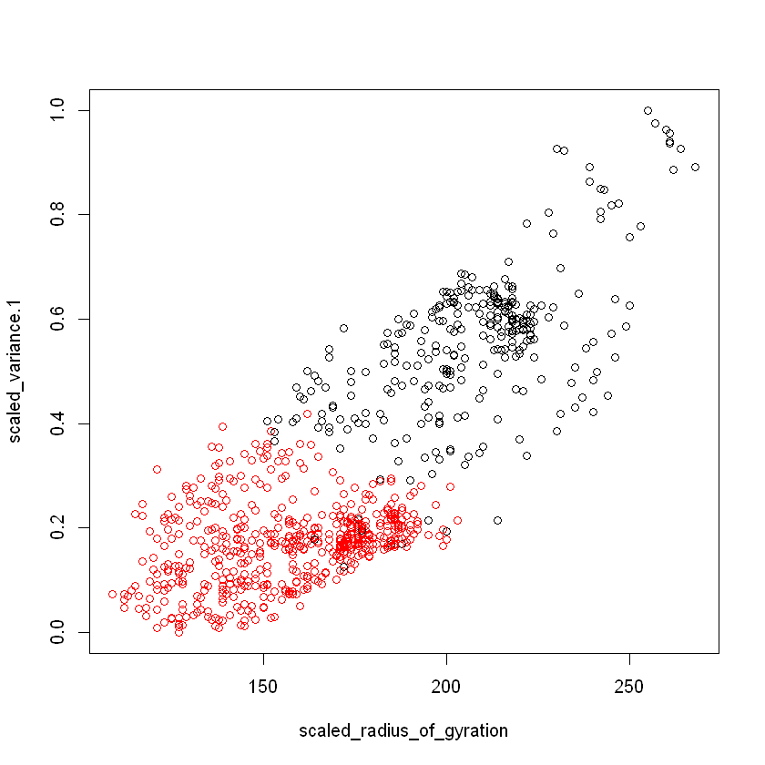

```
xxxxxxxxxx
```

```
plot(datacluster[, c("scaled_radius_of_gyration", "scaled_variance.1")], col = kmeanResult$cluster)
```

```
# Add cluster centers to the existing plot
```

```
points(kmeanResult$centers[, c("scaled_radius_of_gyration", "scaled_variance.1")], col = 1:4, pch = 8, cex = 15)
```

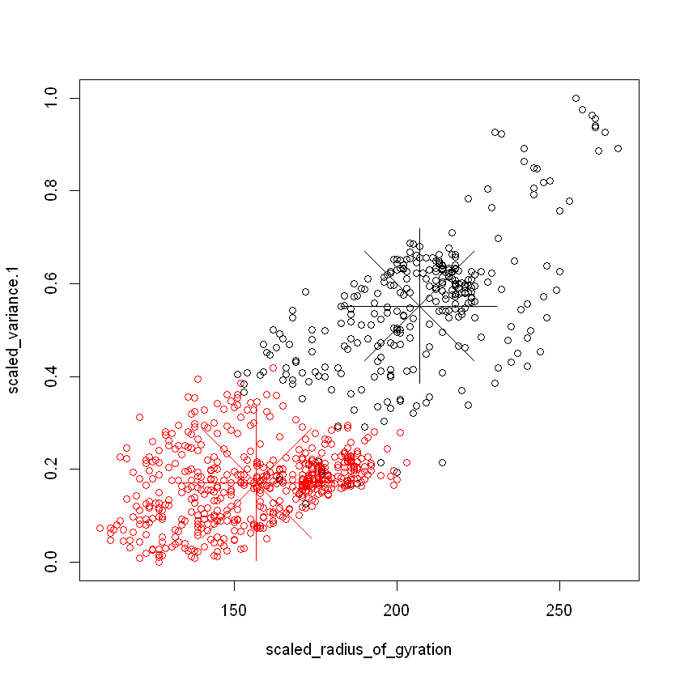

```
xxxxxxxxxx
```

[output not shown]

The visualization suggests that opting for two clusters is the better choice, given that similar clusters are more tightly grouped together, resulting in a more distinct representation of the clusters.

```
xxxxxxxxxx
```

[output not shown]

[output not shown]

### The analysis

In summary, the examination of different cluster sizes demonstrates their varying impact on the accuracy of representing the data. Evaluating overlaps and the cohesion within clusters illustrates the substantial influence of the chosen cluster number on the quality and clarity of the resulting clusters. The initial analysis began with three clusters, aligning with the original class label count. Subsequently, the addition of an extra cluster did not yield improved results, and the exploration continued by reducing the cluster count, which visually demonstrated better clustering than with four clusters.

```
xxxxxxxxxx
```

[output not shown]